# assigment_week2_20180819

Harold Pollack

8/19/2018

This assignment analyzes an activity dataset of steps per five-minute interval, and analyzes the data. It provides practice producing an R markdown file and committing it to GitHub.

```r
library("dplyr", lib.loc="/Library/Frameworks/R.framework/Versions/3.4/Resources/library")
```

```r
library("forecast", lib.loc="/Library/Frameworks/R.framework/Versions/3.4/Resources/library")
library("knitr", lib.loc="/Library/Frameworks/R.framework/Versions/3.4/Resources/library")
library("ggplot2", lib.loc="/Library/Frameworks/R.framework/Versions/3.4/Resources/library")
library("xts", lib.loc="/Library/Frameworks/R.framework/Versions/3.4/Resources/library")
library("gridExtra", lib.loc="/Library/Frameworks/R.framework/Versions/3.4/Resources/library")
library("urca", lib.loc="/Library/Frameworks/R.framework/Versions/3.4/Resources/library")
library("ggpubr", lib.loc="/Library/Frameworks/R.framework/Versions/3.4/Resources/library")
library("VGAM")
library("maxLik")
knitr::opts_chunk$set(echo = TRUE)
```

This markdown file reads and processes activity.csv We begin by using read.csv to read the activity dataset, and printing out some descriptives.

```r
activity <- read.csv("/Users/haroldpollack/Documents/coursera_datascience3/activity.csv")
activity$lsteps<-log(1+activity$steps)
# table(activity$date)
activity$day <-weekdays(as.Date(activity$date))
table(activity$day)
```

```
##
##    Friday    Monday  Saturday    Sunday  Thursday   Tuesday Wednesday
##      2592      2592      2304      2304      2592      2592      2592
```

```r
# table(activity$interval)
str(activity)
```

```
## 'data.frame':    17568 obs. of  5 variables:
##  $ steps   : int  NA NA NA NA NA NA NA NA NA NA ...
##  $ date    : Factor w/ 61 levels "2012-10-01","2012-10-02",..: 1 1 1 1 1 1 1 1 1 1 ...
##  $ interval: int  0 5 10 15 20 25 30 35 40 45 ...
##  $ lsteps  : num  NA NA NA NA NA NA NA NA NA NA ...
##  $ day     : chr  "Monday" "Monday" "Monday" "Monday" ...
```

```r
summary(activity)
```

```
##      steps                date          interval          lsteps
##  Min.   :  0.00   2012-10-01:  288   Min.   :   0.0   Min.   :0.000
##  1st Qu.:  0.00   2012-10-02:  288   1st Qu.: 588.8   1st Qu.:0.000
##  Median :  0.00   2012-10-03:  288   Median :1177.5   Median :0.000
##  Mean   : 37.38   2012-10-04:  288   Mean   :1177.5   Mean   :1.155
##  3rd Qu.: 12.00   2012-10-05:  288   3rd Qu.:1766.2   3rd Qu.:2.565
##  Max.   :806.00   2012-10-06:  288   Max.   :2355.0   Max.   :6.693
##  NA's   :2304     (Other)   :15840                    NA's   :2304
##      day
##  Length:17568
##  Class :character
##  Mode  :character
##
##
##
##
```

Now show some histograms of the step distribution. I also show histographs of log of steps, with and without zeros omitted.

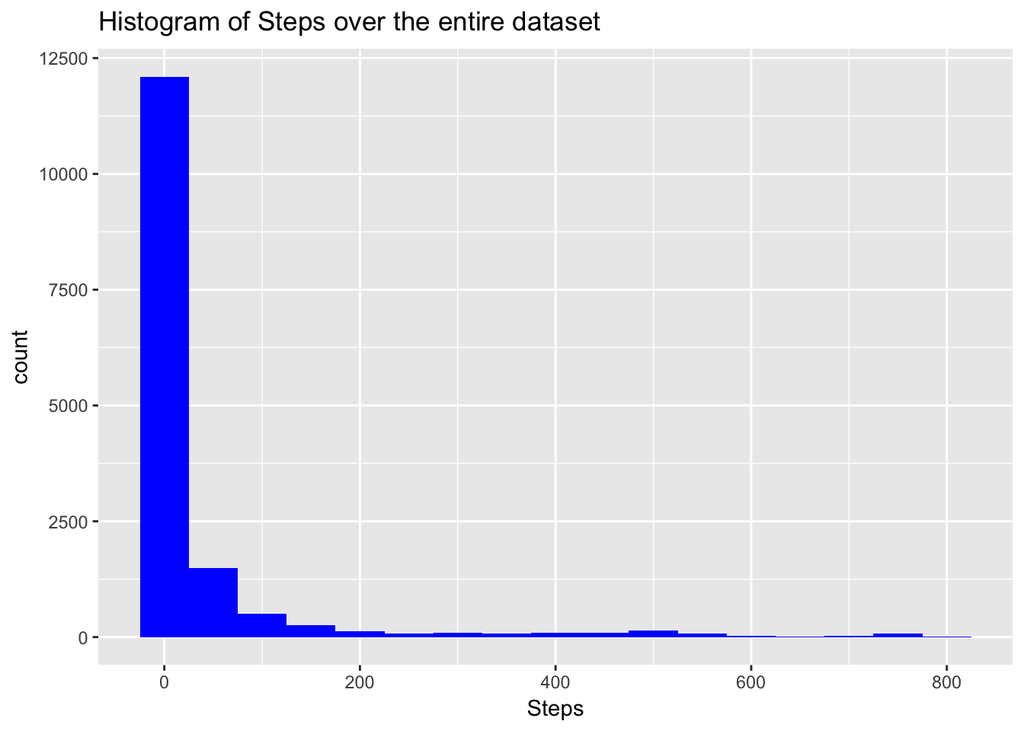

```r
qplot(activity$steps,
      geom="histogram",
      binwidth=50,
      main="Histogram of Steps over the entire dataset",
      fill=I("blue"),
      xlab = "Steps"
      )
```

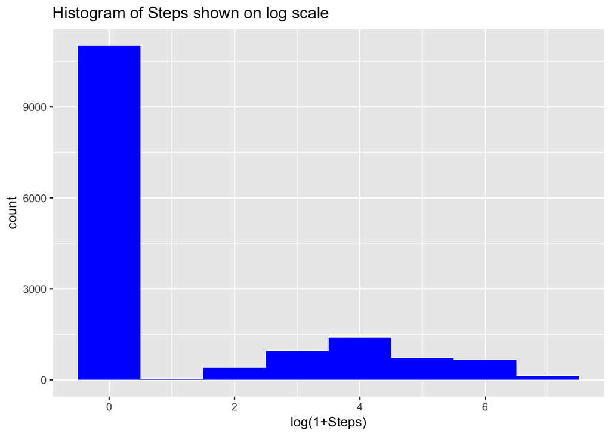

```r
qplot(activity$lsteps,
      geom="histogram",
      binwidth=1,
      main="Histogram of Steps shown on log scale",
      fill=I("blue"),
      xlab = "log(1+Steps)"
      )
```

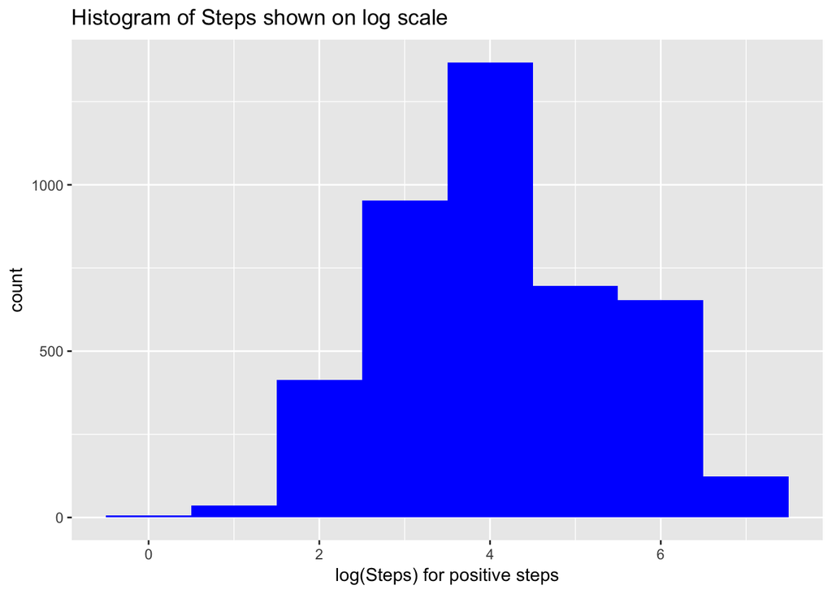

```r
## log of steps
# hist(activity$lsteps,
#      breaks = 10,
#      main="Histogram of Steps shown on log scale",
#      fill=I("blue"),
#      xlab = "log(1+Steps)"
#      )
#
# for the heck of it, let's make a log histogram for the positive values
#
activity$logsteps2 <- log(activity$steps)
# str(activity$logsteps2)
# hist(activity$logsteps2,
#      breaks = 10,
#      main="Histogram of Steps shown on log scale--zeros omitted",
#      fill=I("blue"),
#      xlab = "log(Steps), zeros omitted"
#      )
qplot(activity$logsteps2,
      geom="histogram",
      binwidth=1,
      main="Histogram of Steps shown on log scale",
      fill=I("blue"),
      xlab = "log(Steps) for positive steps"
      )
```

Find which days are weekends

```r
charday <- as.character(activity$day)
table(charday)
```

```
## charday
##    Friday    Monday  Saturday    Sunday  Thursday   Tuesday Wednesday
##      2592      2592      2304      2304      2592      2592      2592
```

```r
dSunday<-as.numeric((activity$day=="Sunday"))
dMonday<-as.numeric((activity$day=="Monday"))
dTuesday<-as.numeric((activity$day=="Tuesday"))
dWednesday<-as.numeric((activity$day=="Wednesday"))
dThursday<-as.numeric((activity$day=="Thursday"))
dFriday<-as.numeric((activity$day=="Friday"))
dSaturday<-as.numeric((activity$day=="Saturday"))
dweekend<-dSunday+dSaturday
table(dweekend)
```

```
## dweekend
##     0     1
## 12960  4608
```

```r
#
# put dweekend into the activity dataset
#
activity$dweekend <- dweekend
#
#    Don't full understand why the below code is wrong
#
# if (activity$day=="Saturday") {week_factor<-"Weekend"
# } else if (activity$day=="Sunday") {week_factor<-"Weekend"
# } else if (activity$day=="Monday") {week_factor<-"Weekday"
# } else if (activity$day=="Tuesday") {week_factor<-"Weekday"
# } else if (activity$day=="Wednesday") {week_factor<-"Weekday"
# } else if (activity$day=="Thursday") {week_factor<-"Weekday"
# } else if (activity$day=="Friday") {week_factor<-"Weekday"}

# table(week_factor)
```

Now find median and mean of steps

```r
steps_median <- median(activity$steps, na.rm = TRUE)
steps_mean <- mean(activity$steps, na.rm = TRUE)
# steps_median
# steps_mean
```

The median number of steps is 0. The mean number of steps is 37.3825996.

Now handle missing values. I replaced with nonnegative predicted values based on a simple regression with day dummies and interval dummies. I then forced the values to be non-negative. A slightly better model would employ censored regression or something like that.

```r
activity$missing_steps <- as.numeric(is.na(activity$steps))
# table(activity$missing_steps)
n_missing <- sum(activity$missing_steps)
```

There are 2304 observations with missing steps. Now let’s run some regressions with non-interacted day and interval dummies for imputation. I would use a more complex approach or at least a Tobit specification for a more substantive problem.

```r
#
#  regression model with non-interacted day and interval dummies
#
model_steps <- lm(steps ~ as.factor(day)+as.factor(interval), data=activity)
# summary(model_steps)
activity$pred_steps=predict(model_steps,activity)
summary(activity$pred_steps)
```

```
##    Min. 1st Qu.  Median    Mean 3rd Qu.    Max.
##  -8.866   6.308  33.237  37.574  53.762 212.313
```

```r
# str(activity$pred_steps)
#
#   set imputed steps to steps when the observations are there
#
activity$imputed_steps<-activity$steps
# summary(activity$imputed_steps)
# str(activity$imputed_steps)
#
#    Still don't see why the below code is wrong. Looping through observations works
# better
#
# if (activity$missing_steps==1) {activity$imputed_steps<-activity$pred_steps
# } else if (activity$missing_steps==0) {activity$imputed_steps<-activity$steps}
# if (activity$missing_steps==1) {activity$imputed_steps_missing<-activity$pred_steps
#
# loop through each observation
#
#    Now loop through each observation for the imputation when steps
#    is missing
#
for(i in 1:nrow(activity))
{
  activity$imputed_steps[i]<- activity$steps[i]
  if(activity$missing_steps[i] == 1)
  {
    #
    #    Note that I want predicted values to be nonnegative. Which I do below.
    #
    activity$imputed_steps[i] <- max(0,activity$pred_steps[i])
  }
}
# summary(activity$imputed_steps_missing)
# str(activity$imputed_steps_missing)

# summary(activity$steps)
summary(activity$imputed_steps)
```

```
##    Min. 1st Qu.  Median    Mean 3rd Qu.    Max.
##    0.00    0.00    0.00   37.63   27.27  806.00
```

```r
# summary(activity$missing_steps)
# str(activity$steps)
# str(activity$imputed_steps)
# str(activity$missing_steps)
imputed_steps <- activity$imputed_steps
activity_date <- activity$date
interval <-activity$interval
```

Now deal with daily averages using aggregate.

```r
#
# First compute average by interval
#
# agg_interval_steps <-
#  aggregate(activity, by=list(interval),
#  FUN=mean, na.rm=TRUE)
day_imputed_steps <- aggregate(imputed_steps,list(activity_day= activity_date),sum)
day_imputed_steps$daily_steps <- day_imputed_steps$x
str(day_imputed_steps)
```

```
## 'data.frame':    61 obs. of  3 variables:
##  $ activity_day: Factor w/ 61 levels "2012-10-01","2012-10-02",..: 1 2 3 4 5 6 7 8 9 10 ...
##  $ x           : num  10130 126 11352 12116 13294 ...
##  $ daily_steps : num  10130 126 11352 12116 13294 ...
```

```r
summary(day_imputed_steps$daily_steps)
```

```
##    Min. 1st Qu.  Median    Mean 3rd Qu.    Max.
##      41    8918   11015   10838   12811   21194
```

```r
#
# now average intervals
#
interval_imputed_steps <- aggregate(imputed_steps,list(activity_interval= interval),mean)
interval_imputed_steps$interval_steps_imputed <- interval_imputed_steps$x
# str(interval_imputed_steps)
summary(interval_imputed_steps)
```

```
##  activity_interval       x            interval_steps_imputed
##  Min.   :   0.0    Min.   :  0.4265   Min.   :  0.4265
##  1st Qu.: 588.8    1st Qu.:  2.7901   1st Qu.:  2.7901
##  Median :1177.5    Median : 34.3043   Median : 34.3043
##  Mean   :1177.5    Mean   : 37.6306   Mean   : 37.6306
##  3rd Qu.:1766.2    3rd Qu.: 53.0260   3rd Qu.: 53.0260
##  Max.   :2355.0    Max.   :206.3609   Max.   :206.3609
```

```r
interval_median_steps <-median(interval_imputed_steps$interval_steps_imputed, na.rm = TRUE)
interval_mean_steps <-mean(interval_imputed_steps$interval_steps_imputed, na.rm = TRUE)
#
# day_imputed_steps
```

The median number of steps per interval is 34.3042524. The mean number of steps per interval is 37.6305777.

```r
#
#  find the maximum imputed steps
#
interval_with_max_steps <- which.max(interval_imputed_steps$interval_steps_imputed)
#
# maximum value
#
max_interval_steps <- max(interval_imputed_steps$interval_steps_imputed)
```

Now show some graphs

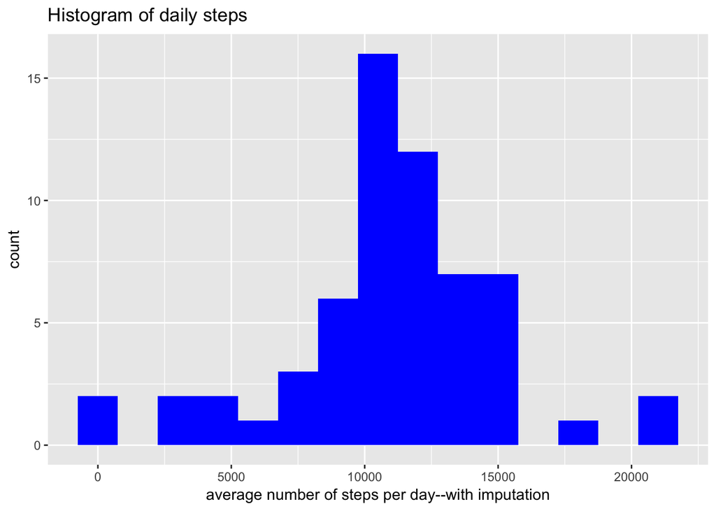

```r
## log of steps
qplot(day_imputed_steps$daily_steps ,
      geom="histogram",
      binwidth=1500,
      main="Histogram of daily steps",
      fill=I("blue"),
      xlab = "average number of steps per day--with imputation"
      )
```

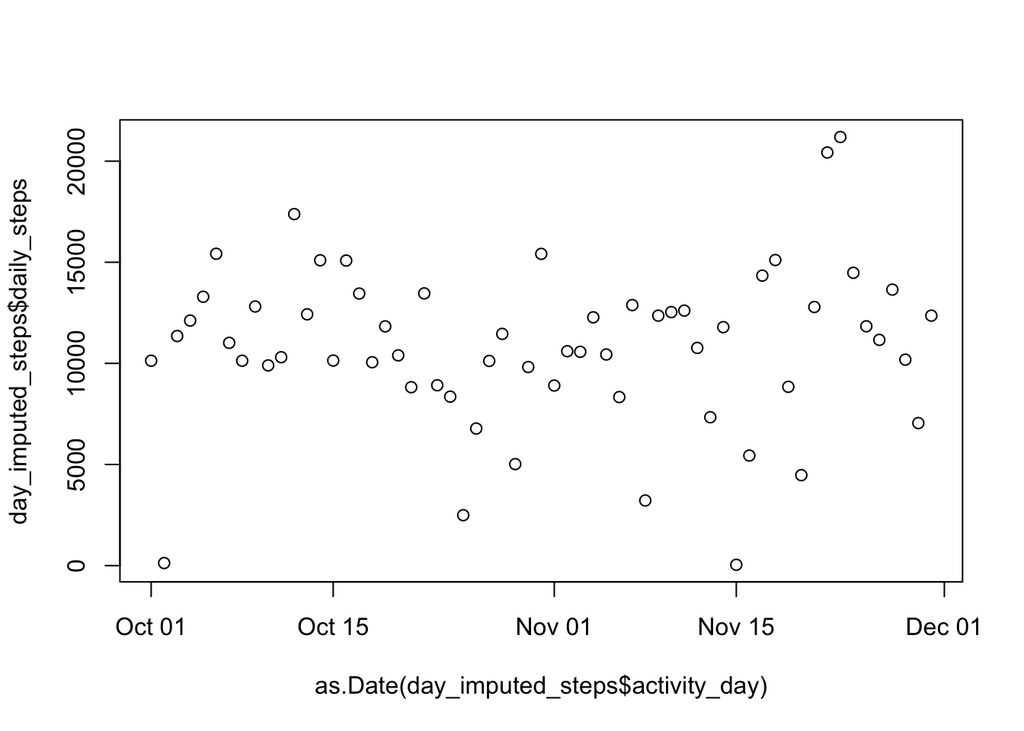

```r
# hist(day_imputed_steps$daily_steps ,
#       breaks = 10,
#      main="Histogram of daily steps",
#      xlab = "average number of steps per day--with imputation",
#      )
#
# time series by day
#
plot(as.Date(day_imputed_steps$activity_day),day_imputed_steps$daily_steps)
```

[figure not shown]

```r
# ggplot(day_imputed_steps)+geom_line(aes(x=activity_day,y=daily_steps))
#
#   Time series by 5-minute interval
#
qplot(interval_imputed_steps$interval_steps_imputed ,
      geom="histogram",
      binwidth=10,
      main="Histogram of daily steps",
      fill=I("blue"),
      xlab = "average number of steps per day--with imputation"
      )
```

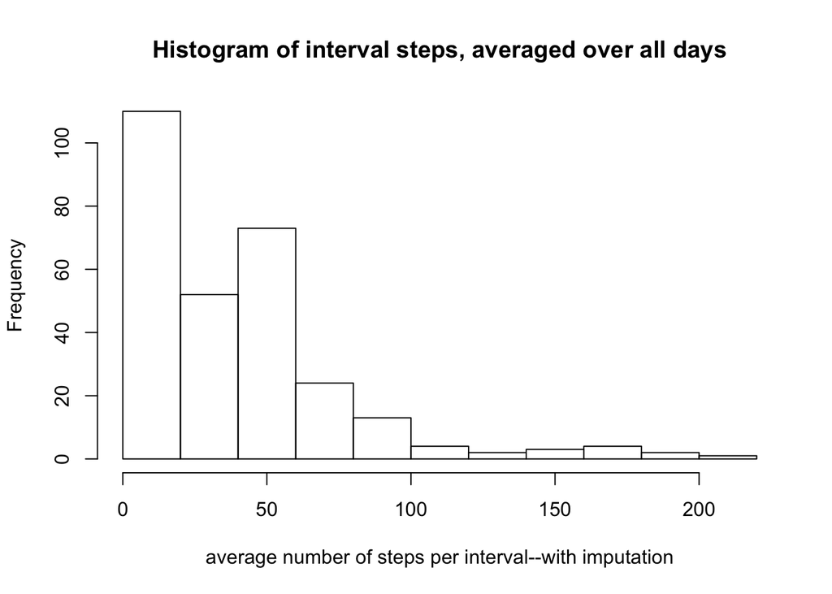

```r
hist(interval_imputed_steps$interval_steps_imputed,
      breaks = 10,
      main="Histogram of interval steps, averaged over all days",
      xlab = "average number of steps per interval--with imputation",
      )
```

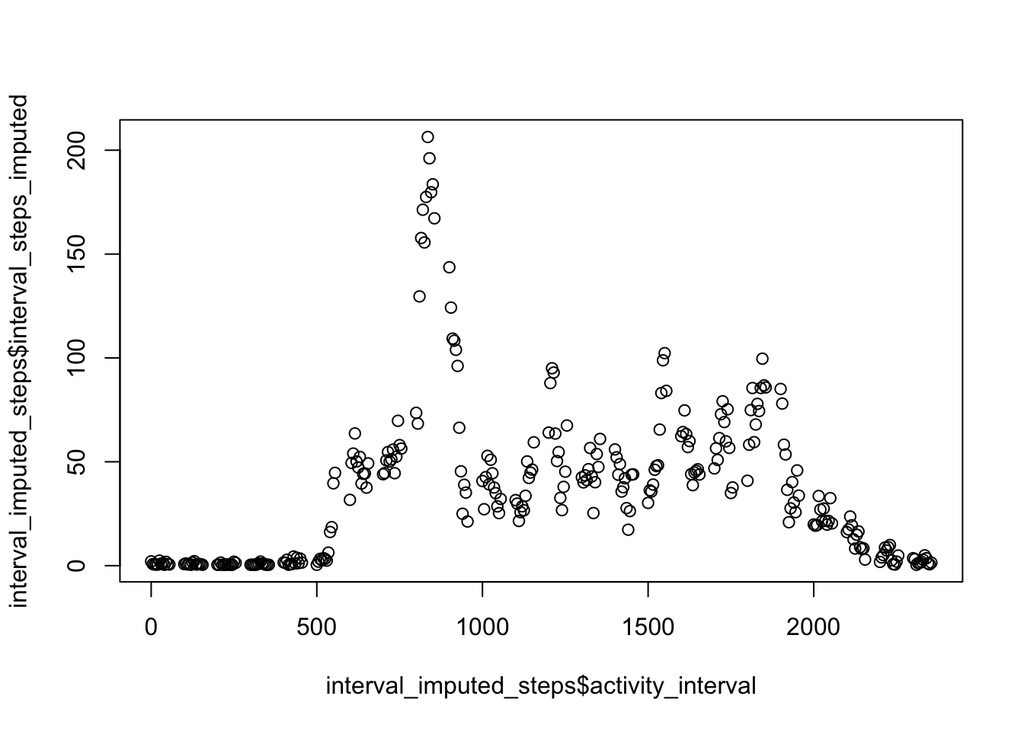

```r
plot(interval_imputed_steps$activity_interval,interval_imputed_steps$interval_steps_imputed)
```

Now let’s examine the weekend/weekday comparison. first the math…

```r
#
# loop through each observation and set up weekend and weekday variables
#
day_imputed_steps$day <- weekdays(as.Date(day_imputed_steps$activity_day))
# table(day_imputed_steps$day)
day_imputed_steps$dSunday<-as.numeric((day_imputed_steps$day=="Sunday"))
day_imputed_steps$dSaturday<-as.numeric((day_imputed_steps$day=="Saturday"))
# table(day_imputed_steps$dSunday)
# table(day_imputed_steps$dSaturday)
day_imputed_steps$dweekend<-day_imputed_steps$dSunday+day_imputed_steps$dSaturday
# table(day_imputed_steps$dweekend)
#
for(i in 1:nrow(day_imputed_steps))
 {
  if(day_imputed_steps$dweekend[i] == 1)
   {
    #
    #    weekend value
    #
     day_imputed_steps$weekend_steps[i] <- day_imputed_steps$daily_steps[i]
     day_imputed_steps$weekday_steps[i] <- NA
   } else if (day_imputed_steps$dweekend[i] == 0)
   {
    #
    #    weekday value
    #
    day_imputed_steps$weekday_steps[i] <- day_imputed_steps$daily_steps[i]
    day_imputed_steps$weekend_steps[i] <- NA
    }
 }
 # str(day_imputed_steps$weekday_steps)
 # str(day_imputed_steps$weekend_steps)
 summary(day_imputed_steps$weekday_steps)
```

```
##    Min. 1st Qu.  Median    Mean 3rd Qu.    Max.    NA's
##      41    8355   10304   10280   12787   21194      16
```

```r
 summary(day_imputed_steps$weekend_steps)
```

```
##    Min. 1st Qu.  Median    Mean 3rd Qu.    Max.    NA's
##    8821   10904   12352   12407   14374   15420      45
```

```r
weekday_interval_median_steps <-round(median(day_imputed_steps$weekday_steps, na.rm = TRUE))
weekday_interval_mean_steps <-round(mean(day_imputed_steps$weekday_steps, na.rm = TRUE))
weekend_interval_median_steps <-round(median(day_imputed_steps$weekend_steps, na.rm = TRUE))
weekend_interval_mean_steps <-round(mean(day_imputed_steps$weekend_steps, na.rm = TRUE))
# weekday_interval_median_steps
# weekday_interval_mean_steps
# weekend_interval_median_steps
# weekend_interval_mean_steps
```

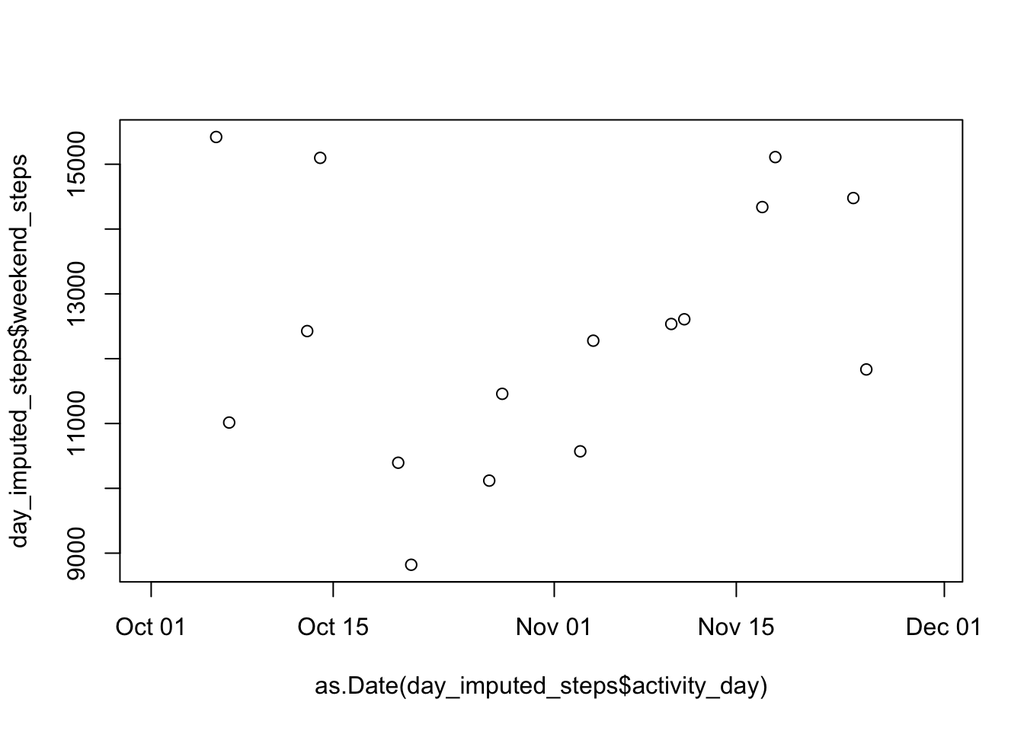

```r
 # q1 <- plot(as.Date(day_imputed_steps$activity_day),day_imputed_steps$weekend_steps)
 # q2 <- plot(as.Date(day_imputed_steps$activity_day),day_imputed_steps$weekday_steps)
 plot(as.Date(day_imputed_steps$activity_day),day_imputed_steps$weekend_steps)
```

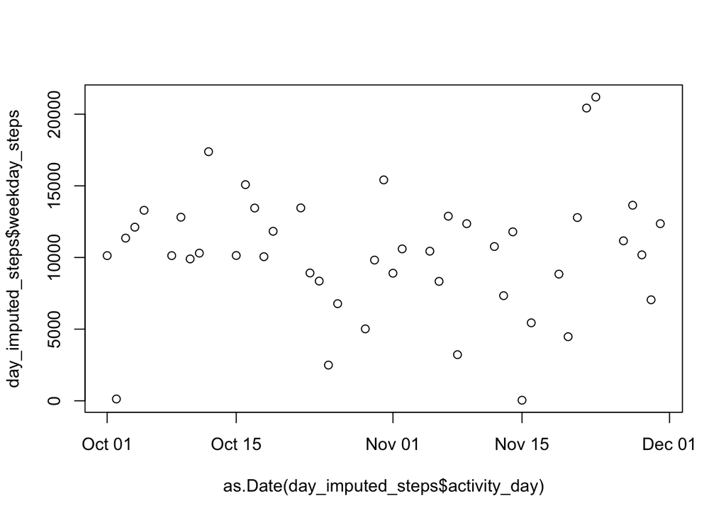

```r
 plot(as.Date(day_imputed_steps$activity_day),day_imputed_steps$weekday_steps)
```

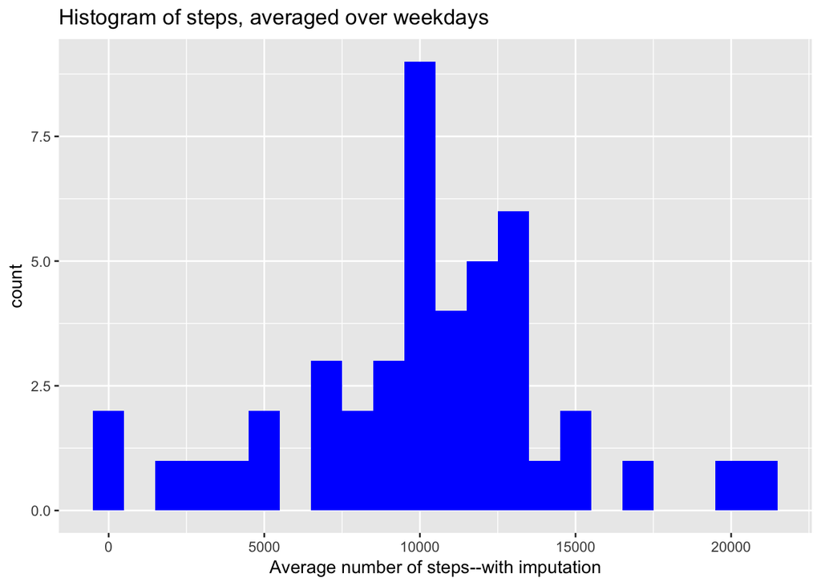

```r
 qplot(day_imputed_steps$weekday_steps ,
      geom="histogram",
      binwidth=1000,
      main="Histogram of steps, averaged over weekdays",
      fill=I("blue"),
       xlab = "Average number of steps--with imputation",
      )
```

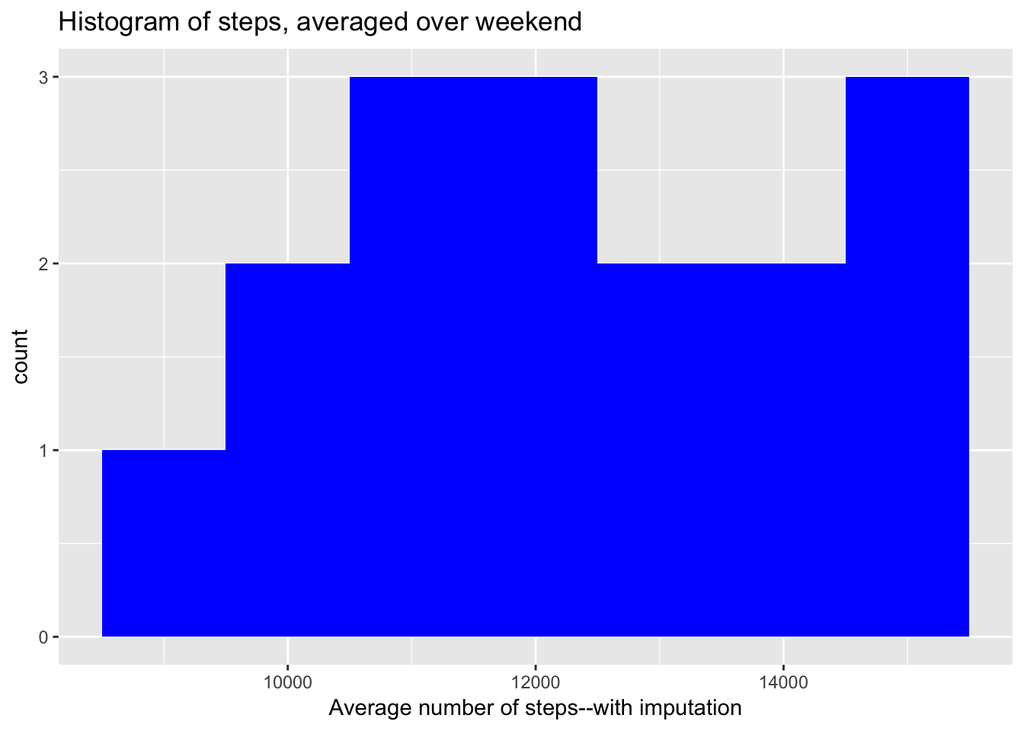

```r
  qplot(day_imputed_steps$weekend_steps ,
      geom="histogram",
      binwidth=1000,
      main="Histogram of steps, averaged over weekend",
      fill=I("blue"),
       xlab = "Average number of steps--with imputation",
      )
```

[figure not shown]

```r
 hist(day_imputed_steps$weekday_steps,
      breaks = 15,
      main="Histogram of interval steps, averaged over weekdays",
      xlab = "Average number of steps per interval--with imputation",
      )
```

[figure not shown]

```r
hist(day_imputed_steps$weekend_steps,
      breaks = 10,
     main="Histogram of interval steps, averaged over weekends",
      xlab = "Average number of steps per interval--with  imputation",
      )
```

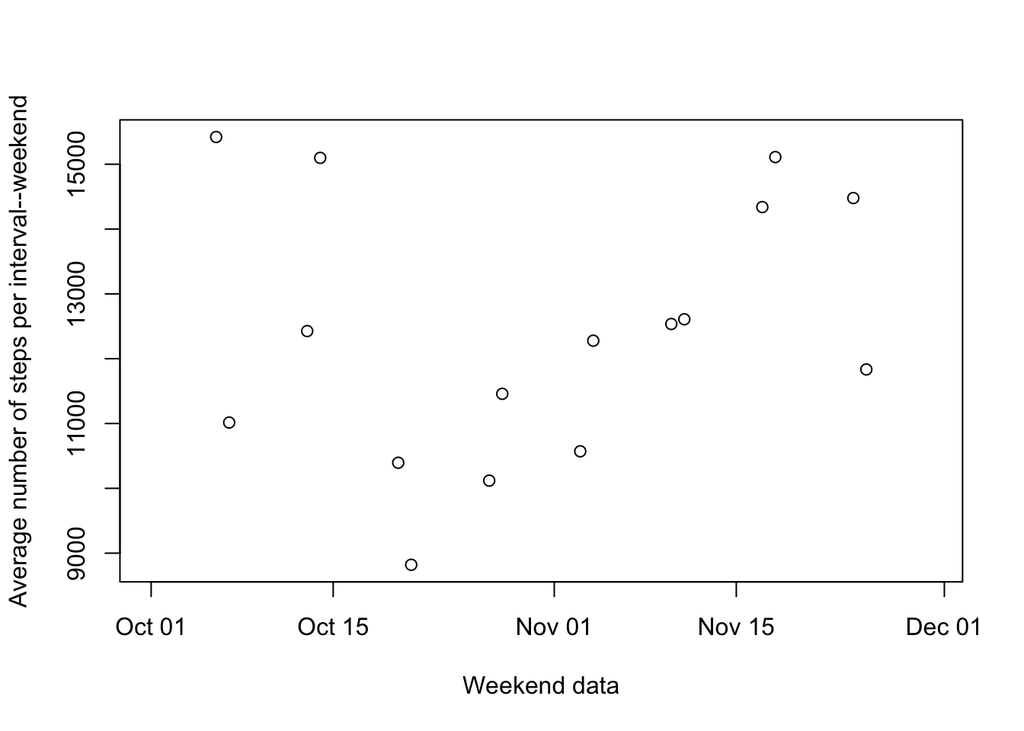

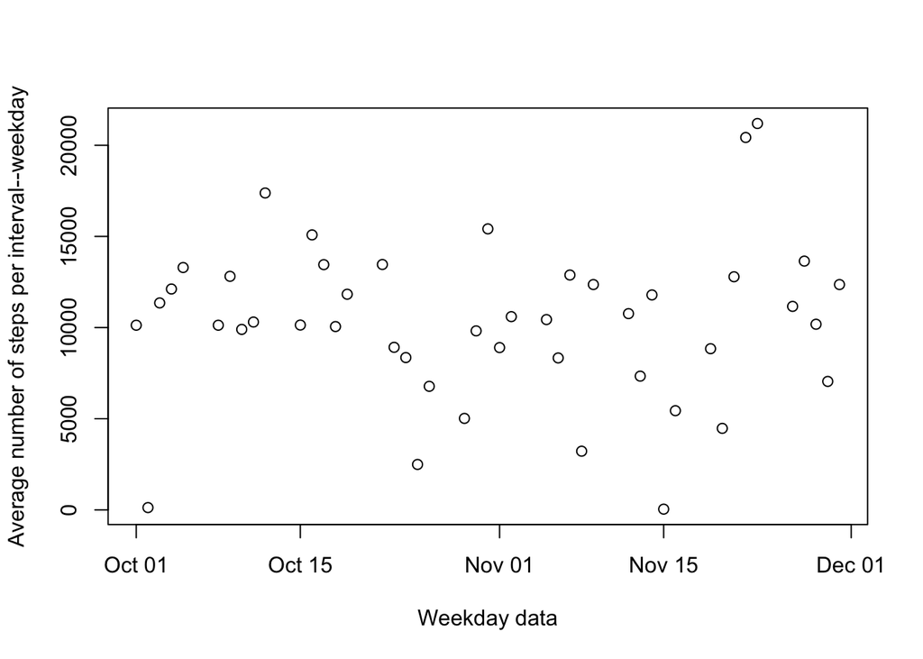

```r
 ggarrange(plot(as.Date(day_imputed_steps$activity_day),day_imputed_steps$weekend_steps, xlab = "Weekend data",ylab = "Average number of steps per interval--weekend"), plot(as.Date(day_imputed_steps$activity_day),day_imputed_steps$weekday_steps, xlab = "Weekday data",ylab = "Average number of steps per interval--weekday"), widths = c(1,2))
```